# Determinig How Well are Done Physical Activities

## Sinopsys

When we talk about keeping our body healthy, frequently we think in the amount of physical exercises we must do, so greater numbers of activities the better. But, what about the quality of the activities?, are we doing them in the right way? In this brief project, we will build a machine learning model in order to predict if a specified physical activity (weight lifting) was done right, based on the measures taken by four sensor. This information was collected as part of the [HAR project](http://groupware.les.inf.puc-rio.br/har) developed by the groupware.les investigation group.

We will made basic exploratory data analysis and built three alternative models for predicting the quality of the observed activities, we will choose the model with an accuracy of at least 80%.

```r
library(dplyr)
library(ggplot2)
library(tidyr)
library(caret)
library(recipes)
library(parallel)
library(doParallel)
```

## Getting Data

Information (training and test data sets) is available on [Groupware page](http://groupware.les.inf.puc-rio.br/har).

```r
train <- read.csv("https://d396qusza40orc.cloudfront.net/predmachlearn/pml-training.csv")
test <- read.csv("https://d396qusza40orc.cloudfront.net/predmachlearn/pml-testing.csv")
```

## Exploratory Data Analysis

```r
dim(train)
str(train)
colnames(train)
```

[output not shown]

Training set has 160 variables and 19622 observations, (test set has 20 observations). In a general review, the main variables are: user name; time stamps; sliding windows; measures for four sensors (glove, armband, lumbar belt and dumbbell) in terms of Euler angles (roll, pitch and yaw) with some calculations (mean, variance, standard deviation, max, min, amplitude, kurtosis and skewness); raw accelerometer, gyroscope and magnetometer readings, and finally classe as our interest variable, as it shows whether an activity was performed correctly (A) or in a wrong way (B, C, D or E), but is only available in training set, instead test set has a new variable named problem_id.

If we make a plot of data according its class, we see that A class is the most frequent with 5580 observations (28%).

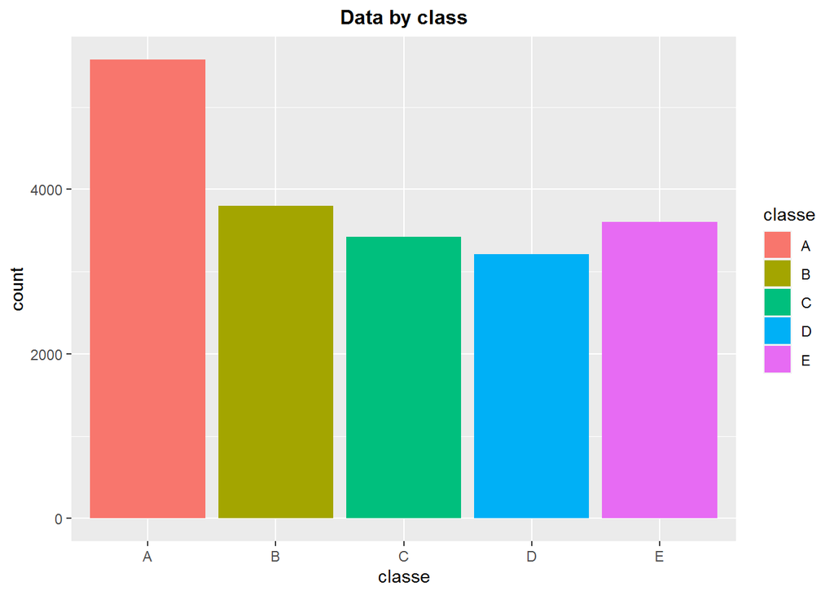

```r
ggplot(data=train,aes(classe,fill=classe))+geom_bar()+labs(title="Data by class")+
  theme(plot.title = element_text(hjust = 0.5, face = "bold", size = 12))
```

```r
table(train$classe)
```

```
##
##    A    B    C    D    E
## 5580 3797 3422 3216 3607
```

```r
prop.table(table(train$classe)) %>% round(digits = 2)
```

```
##
##    A    B    C    D    E
## 0.28 0.19 0.17 0.16 0.18
```